# WEATHER FORECASTING

## HAC

*There are two types of HAC. One is Agglomerative Clustering and other is Decisive Clustering.*

*We use Agglomerative Clustering for our modelling.*

*For Hac I used the same feature and target variables as K-means but I added Raintoday to the feature variables after hyperparameter tuning.*

*Since HAC is computationally expensive $O(n^2)$ and can reach upto $O(n^2logn)$, I ran it on Google colab and pasted the required screenshots of the output.*

**Declaring feature and target variables**

```python
X = data.drop(['RainTomorrow','WindGustDir','WindDir','Location'],axis=1)
y = data['RainTomorrow']
```

```python
X.replace({'RainToday':{'Yes':0,'No':1}},inplace=True)
```

**Running the Agglomerative Clustering model**

```python
hclust = AgglomerativeClustering(n_clusters = 2, affinity='euclidean',linkage='ward').fit(X)
```

```python
hclust.labels_
```

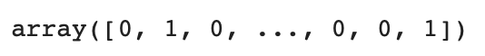

```python
sb.heatmap(pd.crosstab(hclust.labels_,y),annot=True,fmt='d')
```

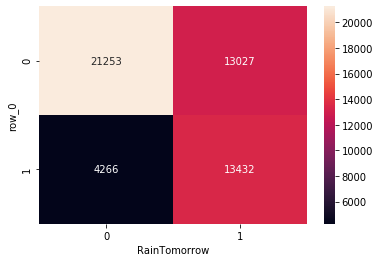

```python
print('Accuracy score is {0:.2f} %\n'.format(accuracy_score((hclust.labels_),y)*100))
print('Precision score is {0:.2f} %\n'.format(precision_score((hclust.labels_),y)*100))
print('Recall score is {0:.2f} %\n'.format(recall_score((hclust.labels_),y)*100))
print('F1 score is {0:.2f} %\n'.format(f1_score((hclust.labels_),y)*100))
```

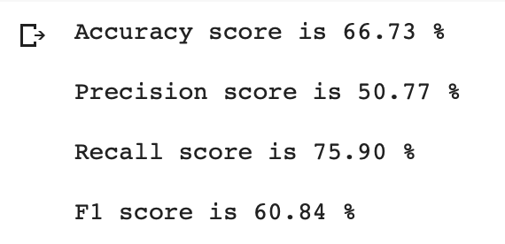

```python
print(classification_report(hclust.labels_,y))
```

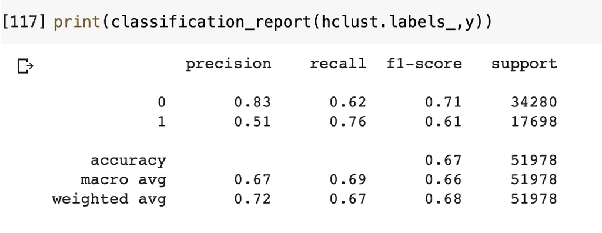

**Dendrogram**

*A dendrogram is a tree-like diagram that records the sequences of merges or splits.*

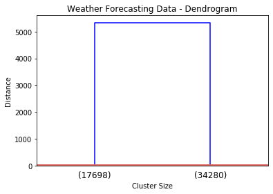

```python
z = linkage(X,"ward")
dendrogram(z,truncate_mode= "lastp", p =2)

plt.title("Weather Forecasting Data - Dendrogram")
plt.xlabel("Cluster Size")
plt.ylabel("Distance")

plt.axhline(y=15)
plt.axhline(5)
plt.axhline(10)
plt.show()
```

**Table summarising HAC**

```python
best_h = {'affinity': 'euclidean',
        'linkage':'ward',
 'Accuracy score': '66.73 %',
'Recall Score':  ' 75.90%',
'Precision Score' : ' 50.77%',
'F1 score' : ' 60.84%'}

hac_table = pd.DataFrame(best_h,index=['best'])
hac_table
```

|  | affinity | linkage | Accuracy score | Recall Score | Precision Score | F1 score |
| --- | --- | --- | --- | --- | --- | --- |
| best | euclidean | ward | 66.73 % | 75.90% | 50.77% | 60.84% |

### Repurpose unsupervised learning algorithms for classification

*When we perform clustering on a binary classification problem, it divides the data into two clusters.*

*It means the data is classified into clusters based on the similarities between the feature variables.*

*From the clusters we can find out which one is 'Yes' or which one is 'No'.*

*There are a lot of measures that can judge the performance of algorithm like precision, recall, accuracy score, f1 score, entropy, gini and purity.*

## Running models on test data

**For test data, I have used the same data preparation methods as train data.**

```python
main = pd.read_csv('test.csv')
```

```python
test = main.drop(columns=['ID'])
```

```python
test.isnull().sum()/test.count().max()*100
```

```
Location          0.000000
MinTemp           0.361705
MaxTemp           0.138525
Rainfall          1.239033
Evaporation      42.450362
Sunshine         46.898569
WindGustDir       7.149454
WindGustSpeed     7.080191
WindDir           2.978298
WindSpeed         2.008619
Humidity          2.685855
Pressure          9.950746
Cloud            38.633215
Temp              2.054795
RainToday         1.239033
dtype: float64
```

```python
test.drop(columns=['Evaporation','Sunshine','Cloud'],inplace=True)
```

```python
for i in ['MinTemp', 'MaxTemp', 'Rainfall', 'WindSpeed', 'Humidity','Temp']:
    test[i]=test.groupby(['Location'])[i].transform(lambda x: x.fillna(x.median()))
```

```python
for i in ['Pressure','WindGustSpeed']:
    test[i].fillna(test[i].median(),inplace=True)
```

```python
for i in ['WindGustDir','WindDir','RainToday']:
    test[i].fillna(test[i].mode()[0],inplace=True)
```

```python
for i in ['MinTemp', 'MaxTemp','Rainfall','WindGustSpeed','WindSpeed','Humidity','Temp','Pressure']:
    IQR = test[i].quantile(0.75) - test[i].quantile(0.25)
    Lower = test[i].quantile(0.25) - (IQR * 3)
    Upper = test[i].quantile(0.75) + (IQR * 3)
    print('{} outliers are values < {} or > {}'.format(i,Lower,Upper))
```

```
MinTemp outliers are values < -19.300000000000004 or > 44.400000000000006
MaxTemp outliers are values < -12.999999999999993 or > 57.69999999999999
Rainfall outliers are values < -6.6000000000000005 or > 8.8
WindGustSpeed outliers are values < -26.0 or > 107.0
WindSpeed outliers are values < -20.0 or > 57.0
Humidity outliers are values < -50.0 or > 165.25
Temp outliers are values < -12.599999999999993 or > 53.89999999999999
Pressure outliers are values < 984.0999999999999 or > 1044.3000000000002
```

```python
def maxt(x,var,upp):
    return np.where(x[var]>upp,upp,x[var])
```

```python
test['Rainfall'] = max_(test,'Rainfall',8.8)
test['WindGustSpeed'] = max_(test,'WindGustSpeed',107)
test['WindSpeed'] = max_(test,'WindSpeed',57)
test['MinTemp'] = max_(test,'MinTemp',44.400000000000006)
test['MaxTemp'] = max_(test,'MaxTemp',57.69999999999999)
test['Pressure'] = max_(test,'Pressure',1044.3000000000002)
test['Humidity'] = max_(test,'Humidity',165.25)
test['Temp'] = max_(test,'Temp',53.89999999999999)
```

```python
test.describe()
```

|  | MinTemp | MaxTemp | Rainfall | WindGustSpeed | WindSpeed | Humidity | Pressure | Temp |
| --- | --- | --- | --- | --- | --- | --- | --- | --- |
| count | 12994.000000 | 12994.000000 | 12994.000000 | 12994.000000 | 12994.000000 | 12994.000000 | 12994.000000 | 12994.000000 |
| mean | 12.499827 | 22.491819 | 1.785570 | 41.797753 | 18.958288 | 57.304140 | 1014.200677 | 20.851485 |
| std | 6.380837 | 7.096097 | 3.042648 | 14.203436 | 9.139686 | 21.656874 | 6.923618 | 6.935161 |
| min | -6.500000 | -3.700000 | 0.000000 | 7.000000 | 0.000000 | 1.000000 | 980.200000 | -4.100000 |
| 25% | 8.000000 | 17.300000 | 0.000000 | 31.000000 | 13.000000 | 42.250000 | 1009.900000 | 15.900000 |
| 50% | 12.200000 | 21.700000 | 0.000000 | 39.000000 | 19.000000 | 58.000000 | 1014.200000 | 20.200000 |
| 75% | 17.100000 | 27.400000 | 2.200000 | 50.000000 | 24.000000 | 73.000000 | 1018.500000 | 25.400000 |
| max | 29.700000 | 46.900000 | 8.800000 | 107.000000 | 57.000000 | 100.000000 | 1037.200000 | 46.200000 |

```python
test_dt = pd.get_dummies(test,columns=['Location','WindGustDir','WindDir','RainToday'],drop_first=True)
```

### Decision Tree

```python
decision_tree_pred = clf.predict(test_dt)
```

```python
decision_tree_pred
```

```
array([0, 1, 0, ..., 1, 1, 0])
```

### K-Means

```python
test_k = test.drop(columns=['Location','WindDir','WindGustDir','RainToday'],axis=1)
```

```python
kmeans_pred = kmeans.predict(test_k)
```

```python
kmeans_pred
```

```
array([0, 1, 1, ..., 1, 1, 0], dtype=int32)
```

### HAC

```python
test_h = test.drop(columns=['Location','WindDir','WindGustDir'],axis=1)
test_h.replace({'RainToday':{'Yes':0,'No':1}},inplace=True)
```

```python
hclust_pred = AgglomerativeClustering(n_clusters = 2, affinity='euclidean',linkage='ward').fit(test_h)
```

```python
hclust_pred.labels_
```

```
array([0, 0, 0, ..., 0, 0, 0])
```

**Making a csv file**

```python
final = pd.DataFrame(list(zip(main['ID'],decision_tree_pred,kmeans_pred,hclust_pred.labels_)),columns=['ID','Decision Tree','K-Means','HAC'])
```

```python
final.head()
```

|  | ID | Decision Tree | K-Means | HAC |
| --- | --- | --- | --- | --- |
| 0 | 1 | 0 | 0 | 0 |
| 1 | 2 | 1 | 1 | 0 |
| 2 | 3 | 0 | 1 | 0 |
| 3 | 4 | 1 | 1 | 0 |
| 4 | 5 | 1 | 1 | 0 |

**Exporting file**

```python
final.to_csv('final.csv',index=False)
```